# The witness veto: what it costs and what it buys

Expected loss over the 96 donors, and a measurement on the simulated QC set (chr10; 2026-10-06)

Author

Fausto Rodríguez-Zapata

Published

October 6, 2026

Variant discovery keeps a CRISP candidate only if the donor’s BC2S3 lines, merged into one witness pool, show at least one ALT read there (math supplement, Section 4.2). The veto was meant to keep only variants observed in the BC2S3 population. This notebook asks what it costs in real alleles and how many false alleles it removes.

**NoteIn short**

## What the veto costs: Eq. 8 over the 96 donors

A real allele of the donor is missed by one line of coverage $\lambda$ with probability $q(\lambda)$ (Section 4.2, Eq. 8), so a witness of lines $i$ misses it with probability $\prod_i q(\lambda_i)$. Each line’s coverage is its CollectWgsMetrics MEAN_COVERAGE where zealgt aligned it (173 lines: the pilot and plate V21), otherwise its demultiplexed read pairs times its batch’s coverage per million pairs (0.070x batch 1, 0.050x batch 2; 1,594 lines). Lines are taken as independent, so these are lower bounds: sibling lines share BC1 and BC2 ancestry.

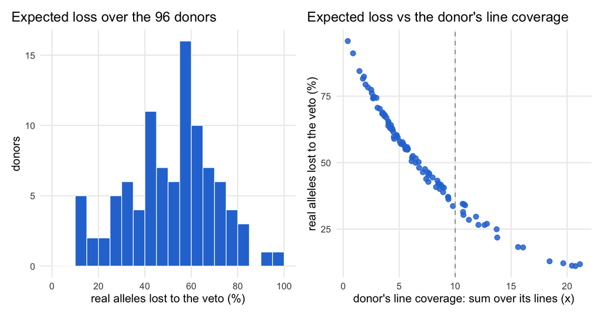

Figure 1

Median over donors: 14 lines, 5.8x of line coverage, **55 %** of real alleles lost; 54 donors lose more than half. The 19 donors with 10x or more lose 11-35 %.

## Measured on the QC set

The QC set (design B, chr10) simulates two founders, TIL18 (*mexicana*) and Gigi (*diploperennis*), each with 5 BC1 pools and 10 lines at six coverages, from reads of the founders’ own assemblies; the truth is each founder’s SNPs against B73 in the low-copy space. The witness was rebuilt from the founder’s 10 lines at 0.05x, 0.4x and 0.8x per line (0.5x, 4x and 8x in all; real donors: median 5.8x), counted at CRISP’s records with the pipeline’s mpileup settings. Three versions:

- **none:** every CRISP record kept;
- **own:** at least one ALT read in the founder’s own lines (the pipeline’s rule);
- **population:** at least one ALT read in its own lines or in the other founder’s lines at the same coverage.

Each kept set then went through step 4 (`score_pooled_likelihood.py`, the pipeline’s arguments). Recall is relative to the true alleles with no veto; precision is TP / (TP + FP) and a lower bound, since the truth misses some real alleles.

Tier A after step 4

| founder | version | kept | TP | FP | recall | precision | Eq. 8 loss |
| --- | --- | --- | --- | --- | --- | --- | --- |
| TIL18 | no veto | 266322 | 196826 | 69496 | 1.00 | 0.739 |  |
| TIL18 | pipeline witness (all 60 line samples, ~27x) | 182838 | 134098 | 48740 | 0.68 | 0.733 |  |
| TIL18 | own, 0.05x per line | 12509 | 9351 | 3158 | 0.05 | 0.748 | 0.9405 |
| TIL18 | population, 0.05x per line | 17047 | 12778 | 4269 | 0.06 | 0.750 |  |
| TIL18 | own, 0.4x per line | 76754 | 57418 | 19336 | 0.29 | 0.748 | 0.6501 |
| TIL18 | population, 0.4x per line | 91804 | 68752 | 23052 | 0.35 | 0.749 |  |
| TIL18 | own, 0.8x per line | 118352 | 88079 | 30273 | 0.45 | 0.744 | 0.4739 |
| TIL18 | population, 0.8x per line | 132068 | 98268 | 33800 | 0.50 | 0.744 |  |
| Gigi | no veto | 324937 | 221441 | 103496 | 1.00 | 0.681 |  |
| Gigi | pipeline witness (all 60 line samples, ~27x) | 218438 | 149112 | 69326 | 0.67 | 0.683 |  |
| Gigi | own, 0.05x per line | 15835 | 11101 | 4734 | 0.05 | 0.701 | 0.9405 |
| Gigi | population, 0.05x per line | 19872 | 13947 | 5925 | 0.06 | 0.702 |  |
| Gigi | own, 0.4x per line | 92366 | 63741 | 28625 | 0.29 | 0.690 | 0.6501 |
| Gigi | population, 0.4x per line | 106826 | 74157 | 32669 | 0.33 | 0.694 |  |
| Gigi | own, 0.8x per line | 141493 | 97147 | 44346 | 0.44 | 0.687 | 0.4739 |
| Gigi | population, 0.8x per line | 154830 | 106817 | 48013 | 0.48 | 0.690 |  |

## ROC: does the witness separate true from false alleles?

Each CRISP record is scored by the witness’s ALT reads at the site; the veto is the cut at one read. Moving the cut gives the ROC: the share of true alleles kept (TPR) against the share of false alleles kept (FPR). For comparison, the same curve with step 4’s likelihood ratio (LLR) as the score.

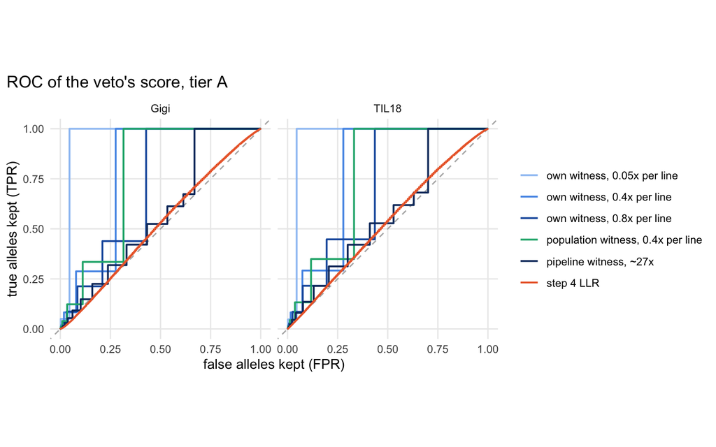

Figure 2

AUROC (0.5 = chance)

| score | Gigi_crisp | Gigi_tierA | TIL18_crisp | TIL18_tierA |
| --- | --- | --- | --- | --- |
| own witness, 0.05x per line | 0.503 | 0.502 | 0.502 | 0.501 |
| own witness, 0.4x per line | 0.513 | 0.506 | 0.513 | 0.507 |
| own witness, 0.8x per line | 0.515 | 0.505 | 0.520 | 0.509 |
| population witness, 0.4x per line | 0.518 | 0.511 | 0.517 | 0.510 |
| pipeline witness, ~27x | 0.511 | 0.495 | 0.513 | 0.499 |
| step 4 LLR | 0.524 | 0.515 | 0.540 | 0.526 |

## Why the witness cannot see these false alleles

A false allele here is a site where the founder is REF but its reads show ALT, mostly reads from a copy the donor has and B73 lacks (a donor-only duplicate, a new TE insertion carrying a gene fragment) that map onto a low-copy B73 site. The low-copy BED is defined on B73, so it cannot remove copies that exist only in the donor.

- **Linked copy** (a tandem duplicate, about 10 % of maize genes; Ac/Ds hops to linked sites): the copy co-segregates with the segment at the site, so the lines that carry the segment show ALT reads exactly as for a real allele. Neither the veto nor any segregation test can tell them apart; for ancestry it is still a valid marker of the segment, and wrong only as a base call.
- **Unlinked copy** (dispersed duplicates, Helitron and Pack-MULE gene fragments, homeologs): ALT reads follow the lines’ ancestry at the copy’s locus, not at the site. A witness pooled over all lines still shows them.

## The veto’s two goals

1. **Remove per-library artefacts**, errors in one BC1 library that an independent set of samples does not reproduce. Step 4’s tier-A rule already asks for ALT reads in at least two BC1 pools, which are separate libraries, so a single-library artefact fails tier A with or without the veto. What only the veto catches is an artefact shared by two or more BC1 libraries but absent from the lines, such as contaminated BC1 material. The simulation cannot test this.
2. **Thin the data set.** It keeps a third to a half of the sites, but at random with respect to truth (AUROC about 0.5), and it preferentially drops alleles that few lines carry. Explicit thinning (the 0.1 cM ancestry grid) does not have that bias, and RTIGER at full marker density takes minutes per donor and chromosome.

## What this does not test

- **Library and sequencing errors, contamination, a wrong plant in a BC1 pool:** none in the simulation (wgsim with a uniform 0.001 error). These are non-reproducible errors, the case the veto can catch; step 4’s B73 zero class and its “ALT reads in at least two BC1 pools” rule for tier A also guard against single-pool errors.
- **Many donors:** the population version here has only one other founder, of another taxon.
- **Independence of lines:** the simulated lines are independent draws; real sibling lines are not.

Sources: QC-set run `ZEAL/results/zealgt_checks/veto_effect_qcset_20261006/run_1130389/` (hazel jobs 1130389, 1130500); data in `witness_veto/`.